# Data Science: An Analysis On College Tuition And Career Pay

by Raymond Su

# Introduction and Background

## The Price Of College

College is an increasingly important aspect of modern skills development. Thus, the worthiness of a university education is a critical question that many people have to answer as they reach adulthood. Oftentimes, the most pressing concern is cost. The scale of modern tuition is considerable, not even including the price of years of time and effort.

As fee-taking, application based institutions with extensive public engagement, raw data on universities is available. Additionally, the rapid growth of universities in recent times has provided a dearth of information on a wide variety of schools and student populations. This is a scenario where the Data Science Pipeline has an opening to exploit.

## The Data Science Pipeline

The field and applicaation of Data Science is varied and myriad. Nonetheless, many projects tend to follow a generalized trend of five distinct steps for investigating a dataset. This tutorial walks through the data science pipeline step by step, illustrating, explanining and justifying the decision making process at every section. For context moving forward, it's relevant to briefly go through all five.

1. First, a data source must be found and collected.
2. Second, the raw data has to be managed and represented into a usable form.
3. Third, the prepared representation of the data should be explored for possible leads towards new insights.
4. Fourth, drawing from data exploration, a hypothesis or predictive relationship needs to be investigated in a more systematic manner.
5. Fifth, a conclusion and discussion should be done on the findings.

## So, let's begin with finding a good data source!

# Part 1 and 2: Data Source, Cleaning and Tidying

## Library Imports

To do our data manipulation and analysis, we'll need to use libraries. Which libraries are most appropriate to use can vary quite a bit from project. Here, some of the them are for data manipulation and support functions (pandas and numpy), others are for data visualization (matplotlib), and two are statistical analysis and machine learning (sklearn and statsmodel).

To figure out whether or not an import will be appropriate for your intended application, it's useful to go through the writeups that come with any reliable library in Python. You can find more about numpy, pandas, matploblib and sklearn through these links.

```python
# Library Imports

# For data manipulation and analysis.
import pandas as pd
import numpy as np

# For data visualization.
import matplotlib.pyplot as plt
from matplotlib.pyplot import figure
from matplotlib import rcParams

# For statistical modeling and machine learning.
from sklearn import linear_model
import statsmodels.api as sm
from operator import attrgetter

# Simple, hard-coded dictionary for translating state names.
# states = {"AL":"Alabama","AK":"Alaska","AZ":"Arizona","AR":"Arkansas","CA":"California","CO":"Colorado","CT":"Connecticut","DE":"Delaware","FL":"Florida","GA":"Georgia","HI":"Hawaii","ID":"Idaho","IL":"Illinois","IN":"Indiana","IA":"Iowa","KS":"Kansas","KY":"Kentucky","LA":"Louisiana","ME":"Maine","MD":"Maryland","MA":"Massachusetts","MI":"Michigan","MN":"Minnesota","MS":"Mississippi","MO":"Missouri","MT":"Montana","NE":"Nebraska","NV":"Nevada","NH":"New Hampshire","NJ":"New Jersey","NM":"New Mexico","NY":"New York","NC":"North Carolina","ND":"North Dakota","OH":"Ohio","OK":"Oklahoma","OR":"Oregon","PA":"Pennsylvania","RI":"Rhode Island","SC":"South Carolina","SD":"South Dakota","TN":"Tennessee","TX":"Texas","UT":"Utah","VT":"Vermont","VA":"Virginia","WA":"Washington","WV":"West Virginia","WI":"Wisconsin","WY":"Wyoming"}
```

# Data Source

We'll be using a few pre-collated sets of raw data on college cost and related information. The specific set was drawn from the Chronicle of Higher Education, a well-known and reliable publication on university data, potential salary data from payscale.com (methodology described here), and income information by state from the United States Census Bureau. The specific files can either be extracted from each site individually or downloaded from a publically available collection here, where some non-mutation reorganization was done to make the data easier to clean.

https://www.payscale.com/college-salary-report/methodology

# Data Representation

Now that we have our raw data in the form of a collection of Comma-Delimited Value (CSV) files, we'll need to get them into a form that we can manipulate and perform analysis on. We'll be using the dataframe structure provided by the pandas library for this purpose. A dataframe stores information in column categories, row-by-row, a common approach that allow for a wide variety of analysis techniques to be applied. Additionally, it's relatively simple and easy to perform mutations based on categories or subsets of the data, a consideration that matters for both cleanup and later analysis.

## The code below sources the data and moves it into a set of local dataframes.

```python
# Getting the raw data, in the form of locally downloaded source files, into a dataframe representation.
tuition_df = pd.read_csv("tuition_cost.csv")
salary_df = pd.read_csv("salary_potential.csv")
state_income_df = pd.read_csv("median-income-2018.csv").rename(columns={'State':'state', 'Median Income':'median_income', 'Standard Error':'std_err'})
tuition_df.head()
```

|  | name | state | state_code | type | degree_length | room_and_board | in_state_tuition | in_state_total | out_of_state_tuition | out_of_state_total |
| --- | --- | --- | --- | --- | --- | --- | --- | --- | --- | --- |
| 0 | Aaniiih Nakoda College | Montana | MT | Public | 2 Year | NaN | 2380 | 2380 | 2380 | 2380 |
| 1 | Abilene Christian University | Texas | TX | Private | 4 Year | 10350.0 | 34850 | 45200 | 34850 | 45200 |
| 2 | Abraham Baldwin Agricultural College | Georgia | GA | Public | 2 Year | 8474.0 | 4128 | 12602 | 12550 | 21024 |
| 3 | Academy College | Minnesota | MN | For Profit | 2 Year | NaN | 17661 | 17661 | 17661 | 17661 |
| 4 | Academy of Art University | California | CA | For Profit | 4 Year | 16648.0 | 27810 | 44458 | 27810 | 44458 |

```python
salary_df.head()
```

|  | rank | name | state_name | early_career_pay | mid_career_pay | make_world_better_percent | stem_percent |
| --- | --- | --- | --- | --- | --- | --- | --- |
| 0 | 1 | Auburn University | Alabama | 54400 | 104500 | 51.0 | 31 |
| 1 | 2 | University of Alabama in Huntsville | Alabama | 57500 | 103900 | 59.0 | 45 |
| 2 | 3 | The University of Alabama | Alabama | 52300 | 97400 | 50.0 | 15 |
| 3 | 4 | Tuskegee University | Alabama | 54500 | 93500 | 61.0 | 30 |
| 4 | 5 | Samford University | Alabama | 48400 | 90500 | 52.0 | 3 |

# Data Tidying And Cleanup

## Dataframe Merge

Now that our data are stored locally, we can start doing some tidying to get them into a more usable form for our analysis. The tuition dataframe tracks facts like the type, cost and degree length of a very large collection of colleges. The salary dataframe records the average pay of students early in their careers (midway through the first five years of their job) and later, after the first five years. We'll need to combine them, extending rows inside the tuition dataframe (where most of our target data is) with rows from the salary dataframe, which includes an important statistic we seek.

To do so, we can use the merge() function included with a pandas dataframe. The function can join rows between two dataframes based on critera, which we specify in the code below as being based on university name. Additionally, we can tack on information from the average state income dataframe as well.

## Notes On Cleanup And Dropped Columns

The merge routine handles quite a bit of the cleanup for us. It only combines rows that match the critera, creating a new dataframe with just the information that met the critera we listed above. While it's not shown, none of the rows ended up having any missing data, since the source data was drawn from a series of reliable and pre-maintained datasets.

We're also going to be dropping and adding a few columns, which is discussed in the next text section.

## Merging the dataframes, adding columns, dropping unneeded ones

```python
# Creating a merged dataframe between the tuition, salary and state income dataframes.
merged_df = tuition_df.merge(salary_df, how='inner', on='name').merge(state_income_df, how='inner', on='state')

# Adding a few columns we'll need later.
merged_df['discount_tuition'] = None

# Dropping unneeded columns.
merged_df = merged_df.drop(["room_and_board", "in_state_total", "out_of_state_total", "make_world_better_percent"], axis = 1)

# Showing the dataframe.
print("Number of rows: " + str(len(merged_df)))
merged_df.head()
```

```
Number of rows: 728
```

|  | name | state | state_code | type | degree_length | in_state_tuition | out_of_state_tuition | rank | state_name | early_career_pay | mid_career_pay | stem_percent | median_income | std_err | discount_tuition |
| --- | --- | --- | --- | --- | --- | --- | --- | --- | --- | --- | --- | --- | --- | --- | --- |
| 0 | Adams State University | Colorado | CO | Public | 4 Year | 9440 | 20456 | 16 | Colorado | 44400 | 81400 | 3 | 73,034 | 3,562 | None |
| 1 | Colorado Christian University | Colorado | CO | Private | 4 Year | 31866 | 31866 | 17 | Colorado | 46800 | 80100 | 2 | 73,034 | 3,562 | None |
| 2 | Colorado College | Colorado | CO | Private | 4 Year | 55470 | 55470 | 5 | Colorado | 53100 | 97900 | 23 | 73,034 | 3,562 | None |
| 3 | Colorado Mesa University | Colorado | CO | Public | 4 Year | 9243 | 22440 | 14 | Colorado | 47800 | 81500 | 7 | 73,034 | 3,562 | None |
| 4 | Colorado School of Mines | Colorado | CO | Public | 4 Year | 18964 | 38584 | 1 | Colorado | 75600 | 139600 | 93 | 73,034 | 3,562 | None |

## Post Merge Table

The number of entries left, comfortably in the hundreds, looks large enough relative to the original dataframe size to do analysis on. While it's not shown here, none of the universities left were 2-year institutions, meaning that we could drop the row altogether. Again, what rows were dropped and why is discussed in more detail later, since it's a little bit cleaner to do so when the table is fully tidied.

## Discount Column

Many schools offer very significant discounts for in-state students, but many schools don't. In the cases where they don't, the values between the out_of_state and in_state tuition columns are equal. This would be a major source of skew when analyzing the data, so we need to mark whether or not has an actual discount associated with their state status. Since it's a binary variable, we can track it is as a column of boolean values. To that end we have created a new column called "discount_tuition".

Below, we iterate through the array and set the value of discount tuition appropriately. Additionally, we do a simple count of the number of public and private schools that offer discounts, to get a sense on what the number is like.

## Doing Processing To Fill Up New Discount Tuition Column

```python
# Tracking which schools offer discounts.
public_same_charge = []
private_same_charge = []
discount_schools = []

merged_df['discount_tuition'] = None

for index, row in merged_df.iterrows():

    # Get the name of the school out.
    name = row["name"]

    # Truth value.
    discount_tuition = True

    if (row["in_state_tuition"] >= row["out_of_state_tuition"]):
        if (row["type"] == "Public"):
            public_same_charge.append(name)
        else:
            private_same_charge.append(name)

        discount_tuition = False
    else:
        discount_schools.append(name)

    # Set the truth value.
    merged_df.at[index, 'discount_tuition'] = discount_tuition

print("The number of public schools that don't discount in-state tuition: " + str(len(public_same_charge)))
print("The number of private schools that don't discount in-state tuition: " + str(len(private_same_charge)))
print("The number of schools that discount in-state tuition: " + str(len(discount_schools)))
merged_df.head()
```

```
The number of public schools that don't discount in-state tuition: 12
The number of private schools that don't discount in-state tuition: 452
The number of schools that discount in-state tuition: 264
```

|  | name | state | state_code | type | degree_length | in_state_tuition | out_of_state_tuition | rank | state_name | early_career_pay | mid_career_pay | stem_percent | median_income | std_err | discount_tuition |
| --- | --- | --- | --- | --- | --- | --- | --- | --- | --- | --- | --- | --- | --- | --- | --- |
| 0 | Adams State University | Colorado | CO | Public | 4 Year | 9440 | 20456 | 16 | Colorado | 44400 | 81400 | 3 | 73,034 | 3,562 | True |
| 1 | Colorado Christian University | Colorado | CO | Private | 4 Year | 31866 | 31866 | 17 | Colorado | 46800 | 80100 | 2 | 73,034 | 3,562 | False |
| 2 | Colorado College | Colorado | CO | Private | 4 Year | 55470 | 55470 | 5 | Colorado | 53100 | 97900 | 23 | 73,034 | 3,562 | False |
| 3 | Colorado Mesa University | Colorado | CO | Public | 4 Year | 9243 | 22440 | 14 | Colorado | 47800 | 81500 | 7 | 73,034 | 3,562 | True |
| 4 | Colorado School of Mines | Colorado | CO | Public | 4 Year | 18964 | 38584 | 1 | Colorado | 75600 | 139600 | 93 | 73,034 | 3,562 | True |

## Tidy Table, And Discussion On Dropped Columns

The table is now tidied.

## Removal of room and board, in-state and out-of-state total cost.

The tuition of a school is the price the institution charges for access to classes, faculty, facilities and opportunity. It is the price that the university believes itself to be worth, enough so that students will pay for it. However, the room and board of a school varies for reasons that can well beyond the simple value of the university's education. It can depend on very local circumstances, from the condition of real estate in a university town to the geographic location of the state. There a lot of factors that influence the room and board that can have very little to do with the factors that the cost of tuition represents. Additionally, the cost of standardized room and board are identical between in-state and out-of-state students, meaning that here it represents an addition by a constant on each row, which won't affect any relationship between in-state and out-of-state tuition that we find. Thus, we choose to remove the room and board column, along with its two dependent columns in-state and out-of-state total cost.

## Removal of "Make World Better Percent"

This column indicates the percentage of students that responded affirmatively to a "make the world better" inquiry. This kind of question is incredibly broad, likely varies school by school for cultural reasons. It's easy for people to interpret such a generic platitude into a very broad critera. This has very little to do with my analysis on school cost, so it was removed.

## And thus, we have a tidied dataset! We can know do some visualization.

### Note: The discussion on the necessity of the discount column is in the previous text cell.

# Part 3: Exploratory Data Analysis And Data Visualization

## Purpose

Exploratory data analysis focuses on what the name implies - exploring the data, looking for hints of deeper and more interesting relationships to explore more fully. Where to start and where to go with exploratory analysis can be very subjective. Oftentimes a good way to start is to begin with something broad and direct, where we might be able to spot a deeper pattern to hone in on.

## Let's begin with something simple and hopeful. Let's plot the two tuition standards, in-state and out-of-state, against the early and mid-career salaries of students from each university.

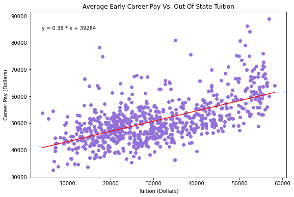

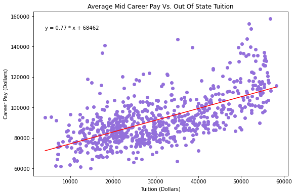

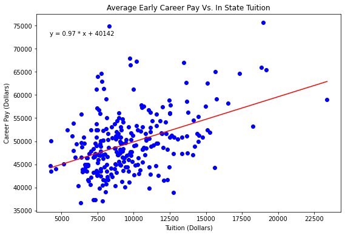

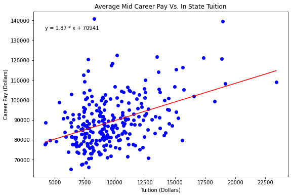

```python
# Plot out-of-state tuition vs early and mid-career pay.

# Create a list of tuples for the variables that will be extracted out of the dataframe.
target_y = [("out_of_state_tuition", "Out Of State Tuition", "early_career_pay", "Average Early Career Pay", "mediumpurple"),
            ("out_of_state_tuition", "Out Of State Tuition", "mid_career_pay", "Average Mid Career Pay", "mediumpurple"),
            ("in_state_tuition", "In State Tuition", "early_career_pay", "Average Early Career Pay", "blue"),
            ("in_state_tuition", "In State Tuition", "mid_career_pay", "Average Mid Career Pay", "blue")]

# Create a dataframe of just the schools that discount in-state tuition.
discount_df = merged_df.loc[merged_df['discount_tuition'] == True]

for (var_x, title_x, var_y, title_y, color) in target_y:
    fig, ax = plt.subplots(figsize = (9,6))

    df_to_use = merged_df

    if (var_x == "in_state_tuition"):
        df_to_use = discount_df

    ax.scatter(df_to_use[var_x], df_to_use[var_y], color = color)
    ax.set_xlabel("Tuition (Dollars)")
    ax.set_ylabel("Career Pay (Dollars)")
    ax.set_title(title_y + " Vs. " + title_x)

    # Plot fit line.
    x_data = df_to_use[var_x]
    y_data = df_to_use[var_y]

    # Get polyfit p.
    p = np.polyfit(x_data, y_data, 1)

    # Get x_fit.
    x_fit = np.linspace(x_data.min(), x_data.max(), 1024)

    # Get y_fit.
    y_fit = np.polyval(p, x_fit)

    # Plot.
    ax.plot(x_fit,y_fit,'r-')

    # List out the slope equation for hte linear fit.
    (m, b) = p
    lin_fit_eq = "y = " + str(round(m, 2)) + " * x + " + str(int(b))
    ax.text(0.15, 0.90 ,lin_fit_eq, ha='center', va='center', transform=ax.transAxes)
```

# Discussion On Scatter Plots

## Analysis, Linfit line, and what to hone in on

It seems like there is some kind of distinguishiable relationship between tuition cost and salary! Even without a linfit line, we can see that for out-of-state tuition, there's a pretty dense pattern of points all along a roughly-but-clearly existent linear trail. The in-state tuition is noticibly more bunched up around the lower half of its range, and is also following a relatively densely packed linear trail.

Thus, we can conclude that there's the potential for a linear relationship. Given that potential, it would be good to include a linear fit line to help distinguish what that relationship might be. Plotting the linfit line, we can tell that while the graph between early and mid career for both in and out of state tuition look similar, they actually don't have similar slopes at all. The slope for mid-career is about double the slope for early career in both cases.

This means we need to decide what to hone in on. From the above reasoning we can say that we're confident enough that a linear relationship exists that we're going to investigate this further. Since the scatterplots look dense, and tuitions are on a continious range, our next step should be looking into creating bins to hone done on a linear relationship between tuition and salary potential.

### Thus, let's take a look at refining the relationship through binning.

## Histogram and Binning

We can create a histogram using the numpy library method. There are a couple of ways to create appropraitely sized bins for a given data distribution. Numpy provides algorithmic options for doing so, and choosing which one fits your set the best is a matter oftentimes a matter of subjective opinion. Since the data distribution looks relatively dense, and eyeball-wise not especially badly distributed, I'll choose the "auto" option here.

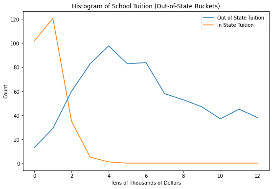

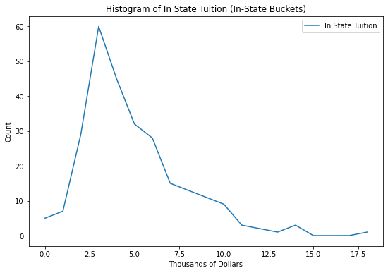

```python
# Histogram and Binning Code
# Make buckets for tuition based on out of state alone.
fig, ax = plt.subplots(figsize = (9,6))
hist_out, out_bin_edges = np.histogram(merged_df["out_of_state_tuition"], bins = "auto")
ax.plot(hist_out, label = 'Out of State Tuition')
ax.set_title("Histogram of School Tuition (Out-of-State Buckets)")
ax.set_xlabel("Tens of Thousands of Dollars")
ax.set_ylabel("Count")

# Histogram discounted in-state tuition based on out-of-state buckets.
hist_in, _ = np.histogram(discount_df["in_state_tuition"], bins = out_bin_edges)
ax.plot(hist_in, label = "In State Tuition")
ax.legend()

# Make buckets for in-state alone.
fig, ax = plt.subplots(figsize = (9,6))
hist_in, in_bin_edges = np.histogram(discount_df["in_state_tuition"], bins = "auto")
ax.plot(hist_in, label = "In State Tuition")
ax.set_title("Histogram of In State Tuition (In-State Buckets)")
ax.set_xlabel("Thousands of Dollars")
ax.set_ylabel("Count")
ax.legend()
```

## Analysis Of Histograms

Using the standard histogram algorithm, we see that bins based on out-of-state tuition alone generate a distribution that looks roughly normal. It's clearly a bit right-skewed from some extremely expensive outliers, but otherwise there's a definite peak.

In-fact, if in-state tuition was being majorly influenced by outside factors like we know them to be from contextual information, then we'd expect to see an uneven distribution even in bins based on discounted tuition alone. This can be seen on the bottom of the two graphs.

### Thus, we should take the out-of-state tuition to be our bins, and we should probably focus on out-of-state tuition moving forward. In-state tuition is clearly under significant influence by outside factors, which we know from contextual information as well (i.e. states setting what in-state tuition should be)

## To make the bins usable in our analysis we need to incorporate them into our dataframe.

Here, we add the right edge of the bins as their own column, for in state and out of state sepearately.

```python
# Adding bins to dataframe.
merged_df['out_tuition_bucket'] = pd.cut(merged_df['out_of_state_tuition'], bins=out_bin_edges, right = False)
merged_df['in_tuition_bucket'] = pd.cut(merged_df['in_state_tuition'], bins=out_bin_edges, right = False)

merged_df['out_tuition_bucket'] = merged_df['out_tuition_bucket'].map(attrgetter('right'))
merged_df['in_tuition_bucket'] = merged_df['in_tuition_bucket'].map(attrgetter('right'))
merged_df.head()
```

|  | name | state | state_code | type | degree_length | in_state_tuition | out_of_state_tuition | rank | state_name | early_career_pay | mid_career_pay | stem_percent | median_income | std_err | discount_tuition | out_tuition_bucket | in_tuition_bucket |
| --- | --- | --- | --- | --- | --- | --- | --- | --- | --- | --- | --- | --- | --- | --- | --- | --- | --- |
| 0 | Adams State University | Colorado | CO | Public | 4 Year | 9440 | 20456 | 16 | Colorado | 44400 | 81400 | 3 | 73,034 | 3,562 | True | 20767.846 | 12442.923 |
| 1 | Colorado Christian University | Colorado | CO | Private | 4 Year | 31866 | 31866 | 17 | Colorado | 46800 | 80100 | 2 | 73,034 | 3,562 | False | 33255.231 | 33255.231 |
| 2 | Colorado College | Colorado | CO | Private | 4 Year | 55470 | 55470 | 5 | Colorado | 53100 | 97900 | 23 | 73,034 | 3,562 | False | 58230.000 | 58230.000 |
| 3 | Colorado Mesa University | Colorado | CO | Public | 4 Year | 9243 | 22440 | 14 | Colorado | 47800 | 81500 | 7 | 73,034 | 3,562 | True | 24930.308 | 12442.923 |
| 4 | Colorado School of Mines | Colorado | CO | Public | 4 Year | 18964 | 38584 | 1 | Colorado | 75600 | 139600 | 93 | 73,034 | 3,562 | True | 41580.154 | 20767.846 |

## Let's re-create the scatterplots based on our new bins, and see if the relationship becomes clearer!

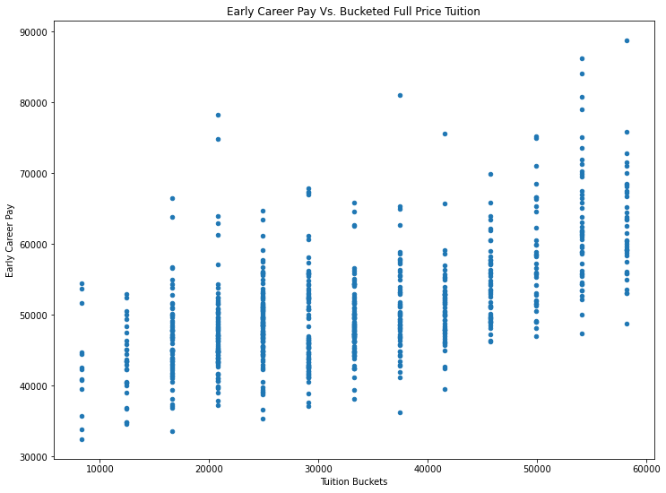

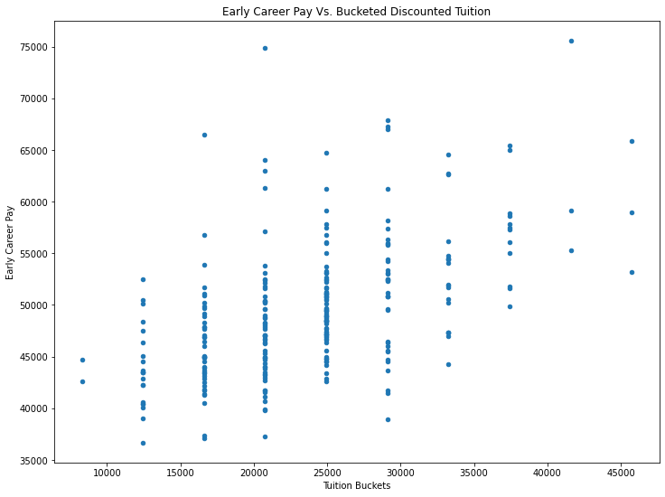

```python
merged_df.plot(kind="scatter", x="out_tuition_bucket", y="early_career_pay", xlabel = "Tuition Buckets", ylabel = "Early Career Pay", title = "Early Career Pay Vs. Bucketed Full Price Tuition", figsize = std_figsize)
plt.savefig("OutTuitionBuckets.png")

# Create an updated discount_df dataframe.
discount_df = merged_df.loc[merged_df['discount_tuition'] == True]
discount_df.plot(kind="scatter", x="out_tuition_bucket", y="early_career_pay", xlabel = "Tuition Buckets", ylabel = "Early Career Pay", title = "Early Career Pay Vs. Bucketed Discounted Tuition", figsize = std_figsize)
plt.savefig("OutTuitionBuckets.png")
```

## Analysis On Binned Scatterplots

Yes, the binned scatterplots make the relationships and individual distributions around each tuition bin much clearer. By eyeball, the distribution for out-of-state looks relatively normally distributed. This means we should take a scatterplot and see it at a deeper level. Again, we're going to choose out-of-state over in-state, because from the histograms it's clear that out-of-state has a more normal distribution.

### Let's make some violin plots!

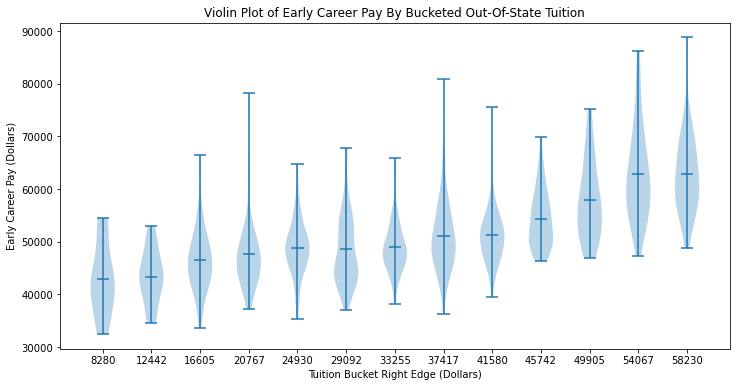

```python
# Violin Plots
bucket_groupby = merged_df.groupby('out_tuition_bucket')

# Violin plots
pay_groups = []
tuition_buckets = []

for bucket, bucket_df in bucket_groupby:
    pay_groups.append(bucket_df['early_career_pay'].tolist())
    tuition_buckets.append(bucket)

fig, ax = plt.subplots(figsize=(12,6))
ax.violinplot(pay_groups, list(range(len(tuition_buckets))), showmeans=True)
ax.set_xticks(list(range(len(tuition_buckets))))
ax.set_xticklabels([int(x) for x in tuition_buckets])
ax.set_xlabel("Tuition Bucket Right Edge (Dollars)")
ax.set_ylabel("Early Career Pay (Dollars)")
ax.set_title("Violin Plot of Early Career Pay By Bucketed Out-Of-State Tuition")
fig.savefig("residual_violin.png", bbox_inches = "tight")
```

## Analysis Of Violin Plots

### This means we might be able to do some hypothesis testing and linear fitting on the relationship between the two.

# Part 4: Hypothesis Testing And Linear Fit

## From our EDA, we think tuition and career pay are linearly related with each other. We can use the sklearn machine learning library to test this hypothesis.

### Here, we create a regression using sklearn.

```python
# Linfit time.

early_career_pay_lst = []
tuition_buckets = []
bucket_groups = []

for key, group_df in bucket_groupby:

    # Storing the life expectancies into the early_career_pay_lst.
    # Storing the year as well.
    early_career_pay_lst.extend(group_df["early_career_pay"].tolist())
    tuition_buckets.extend(group_df["out_tuition_bucket"].tolist())
    bucket_groups.append(key)

# Setting the array of arrays of life expectancy and the array of tuition_buckets as independent and dependent variables.
ind, dep = [ [elem] for elem in tuition_buckets], early_career_pay_lst

# Fitting the independent variables to the dependent set.
lm = linear_model.LinearRegression()
lm.fit(ind,dep)
```

```
LinearRegression()
```

Let's plot the regression against the scatterplot as a sanity check.

```
The fitted model as a
y = 0.3753773391924552 * x + 38672.43037297228
```

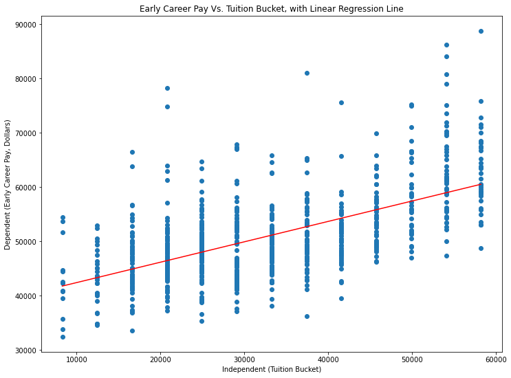

```python
# Getting the m and b coefficients for a linear regression fit.
m = lm.coef_[0]
b = lm.intercept_

# Printing out the equation for the linear regression line in y = m*x + b form.
print("The fitted model as a ")
print("y = " + str(m) + " * x + " + str(b))

# For use in plotting below.
fig, ax = plt.subplots(figsize = std_figsize)

# Creating a scatterplot plus linear regression line.
ax.scatter(ind, dep)
ax.set_xlabel("Independent (Tuition Bucket)")
ax.set_ylabel("Dependent (Early Career Pay, Dollars)")
ax.set_title("Early Career Pay Vs. Tuition Bucket, with Linear Regression Line")

# Plotting the linear fit line.
ax.plot(ind, lm.predict(ind), color='red')
```

Looks good! Goes right through the middle of the scatterplot's approximate median. We should take a look at the residuals last.

```python
# Create a linear model based on the dependent and independent variables from the interaction model.
lin_fit = sm.OLS(dep, ind)
fitted_linear_model = lin_fit.fit()

# Extract the p-values.
p_values = fitted_linear_model.summary2().tables[1]['P>|t|']

# Print the p-values.
print(p_values)
```

[output not shown]

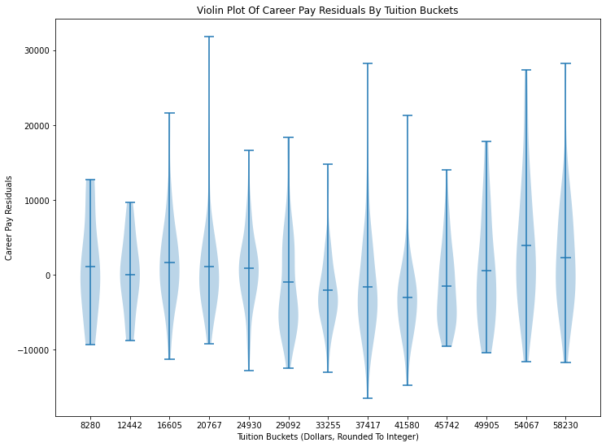

```python
# Exercise 3
residuals = []

# Iterating through the groupby object and getting the dataframe associated with each group.
# We'll use each group_df to extract a list of that year's life expectancies.
for key, group_df in bucket_groupby:

    # Calculate the predicted value.
    predicted_value = m * key + b

    # Calculate the residuals for the whole group_df and append it to the residuals list.
    residuals.append(list(map(lambda x: x - predicted_value, group_df["early_career_pay"].tolist())))

# Creating the violin plot using the example code.
figure(figsize=std_figsize)
rounded_bucket_groups = [int(x) for x in bucket_groups]
plt.violinplot(residuals, list(range(len(rounded_bucket_groups))), showmeans=True)
plt.xlabel("Tuition Buckets (Dollars, Rounded To Integer)")
plt.ylabel("Career Pay Residuals")
plt.title("Violin Plot Of Career Pay Residuals By Tuition Buckets")
plt.xticks(list(range(len(rounded_bucket_groups))), labels=rounded_bucket_groups)
plt.savefig("violin_residuals.png")
```

## Residual Comments

The residuals are a plot of the error distribution for our linear model. Ideally, they should be centered around 0, with a relatively normal distribution and equally sized distribution around each residual. Here, the residuals are centered roughly around 0, and each distribution is relatively normal. However, there's clearly noise and jumps in the error, which probably indicates that there are interaction factors that we didn't account for.

Accounting for interaction factors is another process that can take some more EDA to establish. The data might be in our set or not, and it requires some finesse and trial and error to solve. But at the very least, our model certainly reveals that there is likely a strong correlation between tuition and salary.

# Conclusion

Exploring the data, we saw what looked like a correlation between tuition and early salary pay. We chose out-of-state tuition because the distribution is more normal between colleges, and early salary pay because there are likely many factors that influence later career pay beyond the scope of university education. Using the a linear fit model, we found evidence for a strnog relationship, but it's likely one that needs to be refined by including more interaction factors into our investigation.